# 통계적 가설 검정

Jun

2020-03-15

[figure not shown]

**출처: [**Do it! 쉽게 배우는 R 데이터 분석**](http://www.kyobobook.co.kr/product/detailViewKor.laf?ejkGb=KOR&mallGb=KOR&barcode=9791187370949&orderClick=LEa&Kc=)**  
**Github Code: [Jun4871 Github](https://github.com/Jun4871/copy_with_R_book/blob/master/Klusterling.Rmd)**

# 개요

통계 분석은 크게 기술 통계와 추론 통계로 나눌 수 있다. 데이터를 요약해 설명하는 것을 **‘기술통계’** 라고 한다. 그리고 단순히 숫자를 요약하는 것을 넘어 어떤 값이 바생할 확률을 계산하는 통계 기법을 **‘추론 통계’**라 한다. 일반적으로 통계 분석을 수행했다는 것은 추론 통계를 이용해 가설 검정을 했다는 의미이다. 기술 통계 분석에서 집단 간 차이가 있는 것으로 나타났더라도 이는 우연에 의한 차이일 수 있다. 데이터를 이용해 신뢰할 수 있는 결론을 내리려면 유의확률을 계산하는 통계적 가설 검정 절차를 거쳐야 한다.

유의확률을 이용해 가설을 검정하는 방법을 **’통계적 가설 검정’이라고 한다. ’유의확률’은 실제로는 집단 간 차이가 없는데 우연히 차이가 있는 데이터가 추출될 확률을 의미한다. 통계 분석을 실시한 결과 유의확률이 크게 나타났다면 ’집단 간 차이가 통계적으로 유의하지 않다.’고 해석한다. 이는 실제로 차이가 없더라도 우연에 의해 이 정도 차이가 관찰될 가능성이 크다는 의미이다. 반대로 유의확률이 작다면 ’집단 간 차이가 통계적으로 유의하다’고 해석한다. 이는 실제로 차이가 없는데 우연히 이 정도의 차이가 관찰될 가능성이 작다. 우연이라고 보기 힘들다는 의미이다.

# t 검정 - 두 집단의 평균 비교

’t 검정(t-test)’은 두 집단의 평균에 통계적으로 유의한 차이가 있는지 알아볼 때 사용하는 통계 분석 기법이다.

### compact 자동차와 suv 자동차의 도시 연비 t 검정

ggplot2 패키지의 mpg 데이터를 이용해 t 검정을 수행하는 방법을 알아보자. 소형차와 suv가 도시 연비에서 통계적으로 유의한 차이가 있는지를 알아보자.

```r
mpg <- as.data.frame(ggplot2::mpg)

library(dplyr)
mpg_diff <- mpg %>%
  select(class, cty) %>%
  filter(class %in% c("compact","suv"))

head(mpg_diff)
```

|  | class | cty |
| --- | --- | --- |
| 1 | compact | 18 |
| 2 | compact | 21 |
| 3 | compact | 20 |
| 4 | compact | 21 |
| 5 | compact | 16 |
| 6 | compact | 18 |

```r
table(mpg_diff$class)
```

```
##
## compact     suv
##      47      62
```

### t 검정

t-test() 함수를 사용하여 t검정을 해보자. 앞에서 추출한 mpg_diff 데이터를 지정하고 ~ 기호를 이용해 비교값인 cty 변수와 class 변수를 지정하면 된다. t 검정은 비교하는 집단의 분산(값이 퍼져있는 정도)이 같은지 여부에 따라 적용하는 공식이 다르다. 여기서는 집단 간 분산이 같다고 가정하고 var.equal = TRUE 옵션을 지정한다.

```r
t.test(data = mpg_diff, cty ~ class, var.equal = TRUE)
```

```
##
##  Two Sample t-test
##
## data:  cty by class
## t = 11.917, df = 107, p-value < 2.2e-16
## alternative hypothesis: true difference in means is not equal to 0
## 95 percent confidence interval:
##  5.525180 7.730139
## sample estimates:
## mean in group compact     mean in group suv
##              20.12766              13.50000
```

출력된 t 검정 결과에서 ‘p-value’가 유의확률을 의미한다. 일반적으로 유의확률 5%를 기준으로 삼고, p-value가 0.05 미만이면 ’집단 간 차이가 통계적으로 유의하다’고 해석한다. 실제로는 차이가 없는데 이런 정도의 차이가 우연히 관찰된 확률이 5%보다 작다면, 이 차이를 우연이라고 보기 어렵다고 결론 내리는 것이다. ’p-value’<2.2e-16’ 의 의미는 2.2 앞에 0이 16개 있는 값( 2.2 x 10 - 16승)보다 작다는 의미이다. p-value가 0.05 보다 작기 때문에 이 분석 결과는 ’compact 와 suv 간 평균 도시 연비 차이가 통계적으로 유의하다’고 해석할 수 있다.

### 일반 휘발유와 고급 휘발유의 도시 연비 t 검정

이번에는 일반 휘발유를 사용하는 자동차와 고급 휘발유를 사용하는 자동차 간 도시 연비 차이가 통계적으로 유의한지 알아보자. 두 연료를 사용하는 자동차를 추출한 후 t 검정을 실시해보도록 하자.

```r
mpg_diff2 <- mpg %>%
  select(fl, cty) %>%
  filter(fl %in% c("r", "p"))

table(mpg_diff2$fl)
```

```
##
##   p   r
##  52 168
```

```r
t.test(data = mpg_diff2, cty ~ fl, var.equal = TRUE)
```

```
##
##  Two Sample t-test
##
## data:  cty by fl
## t = 1.0662, df = 218, p-value = 0.2875
## alternative hypothesis: true difference in means is not equal to 0
## 95 percent confidence interval:
##  -0.5322946  1.7868733
## sample estimates:
## mean in group p mean in group r
##        17.36538        16.73810
```

분석 결과를 보면 p-value 가 0.05 보다 큰 0.2875이다. 실제로는 차이가 없는데 우연에 의해 이런 결과가 관찰될 확률이 28.75라는 의미이다. 따라서 ‘일반 휘발유와 고급 휘발유를 사용하는 자동차 간 도시 연비 차이가 통계적으로 유의하지 않다’고 결론 내릴 수 있다. 출력 결과의 ’sample estimates’ 부분을 보면 고급 휘발유 자동차의 도시 연비 평균이 0.6 정도 높지만 이런 정도의 차이는 우연히 발생했을 가능성이 크다고 해석하는 것이다.

### 상관분석 - 두 변수의 관계성 분석

ggplot2의 패키지 economics 데이터를 이용해서 unemploy 와 pce 간의 통계적으로 유의한 상관관계가 있는지 알아보도록 하자. cor.test()를 이용하면 상관분석을 할 수 있다.

```r
economics <- as.data.frame(ggplot2::economics)
cor.test(economics$unemploy, economics$pce)
```

```
##
##  Pearson's product-moment correlation
##
## data:  economics$unemploy and economics$pce
## t = 18.63, df = 572, p-value < 2.2e-16
## alternative hypothesis: true correlation is not equal to 0
## 95 percent confidence interval:
##  0.5608868 0.6630124
## sample estimates:
##       cor
## 0.6145176
```

출력 결과를 보면 p-value가 0.05 미만이므로, 실업자 수와 개인 소비 지출의 상관이 통계적으로 유의하다고 해석할 수 있다. 출력 결과 맨 아래 ’cor’이 상관계수를 의미한다. 상관계수가 0.61이므로, 실업자 수와 개인 소비 지출은 한 변수가 증가하면 다른 변수가 증가하는 정비례 관계임을 알 수 있다.

### 상관행렬 히트맵

여러 변수의 관련성을 한 번에 알아보고자 할 경우, 모든 변수의 상관 관계를 나타낸 상관행렬을 만든다. 상관행렬을 보면 어떤 변수끼리 관련이 크고 적은지 파악할 수 있다. cor() 함술늘 사용하면 상관행렬을 만들 수 있다.

```r
head(mtcars)
```

|  | mpg | cyl | disp | hp | drat | wt | qsec | vs | am | gear | carb |
| --- | --- | --- | --- | --- | --- | --- | --- | --- | --- | --- | --- |
| Mazda RX4 | 21.0 | 6 | 160 | 110 | 3.90 | 2.620 | 16.46 | 0 | 1 | 4 | 4 |
| Mazda RX4 Wag | 21.0 | 6 | 160 | 110 | 3.90 | 2.875 | 17.02 | 0 | 1 | 4 | 4 |
| Datsun 710 | 22.8 | 4 | 108 | 93 | 3.85 | 2.320 | 18.61 | 1 | 1 | 4 | 1 |
| Hornet 4 Drive | 21.4 | 6 | 258 | 110 | 3.08 | 3.215 | 19.44 | 1 | 0 | 3 | 1 |
| Hornet Sportabout | 18.7 | 8 | 360 | 175 | 3.15 | 3.440 | 17.02 | 0 | 0 | 3 | 2 |
| Valiant | 18.1 | 6 | 225 | 105 | 2.76 | 3.460 | 20.22 | 1 | 0 | 3 | 1 |

```r
car_cor <- cor(mtcars) # 상관행렬 생성
round(car_cor, 2) # 소수점 셋째 자리에서 반올림해 출력
```

```
##        mpg   cyl  disp    hp  drat    wt  qsec    vs    am  gear  carb
## mpg   1.00 -0.85 -0.85 -0.78  0.68 -0.87  0.42  0.66  0.60  0.48 -0.55
## cyl  -0.85  1.00  0.90  0.83 -0.70  0.78 -0.59 -0.81 -0.52 -0.49  0.53
## disp -0.85  0.90  1.00  0.79 -0.71  0.89 -0.43 -0.71 -0.59 -0.56  0.39
## hp   -0.78  0.83  0.79  1.00 -0.45  0.66 -0.71 -0.72 -0.24 -0.13  0.75
## drat  0.68 -0.70 -0.71 -0.45  1.00 -0.71  0.09  0.44  0.71  0.70 -0.09
## wt   -0.87  0.78  0.89  0.66 -0.71  1.00 -0.17 -0.55 -0.69 -0.58  0.43
## qsec  0.42 -0.59 -0.43 -0.71  0.09 -0.17  1.00  0.74 -0.23 -0.21 -0.66
## vs    0.66 -0.81 -0.71 -0.72  0.44 -0.55  0.74  1.00  0.17  0.21 -0.57
## am    0.60 -0.52 -0.59 -0.24  0.71 -0.69 -0.23  0.17  1.00  0.79  0.06
## gear  0.48 -0.49 -0.56 -0.13  0.70 -0.58 -0.21  0.21  0.79  1.00  0.27
## carb -0.55  0.53  0.39  0.75 -0.09  0.43 -0.66 -0.57  0.06  0.27  1.00
```

출력된 상관행렬을 보면 mtcars의 11개 변수가 서로 얼마나 관련되어 있는지 알 수 있다. mpg(연비) 행과 cyl(실린더 수)열이 교차되는 부분을 보면 상관계수가 -0.85이므로, 연비가 높을수록 실린더 수가 적은 경향이 있다는 것을 알 수 있다. cyl 과 wt(무게)의 상관계수가 0.78이므로, 실린더 수가 많을수록 자동차가 무거운 경향이 있다는 것을 알 수 있다.

### 상관계수 표현

여러 변수로 상관행렬을 만들면 너무 많은 숫자로 구성되기 때문에 변수들의 관계를 파악하기 쉽지 않다. 이럴 때 corrplot 패키지의 corrplot() 함수를 사용하여 상관행렬을 히트맵으로 만들면 변수들의 관계를 쉽게 파악할 수 있다. 히트맵은 값의 크기를 색깔로 표현한 그래프이다.

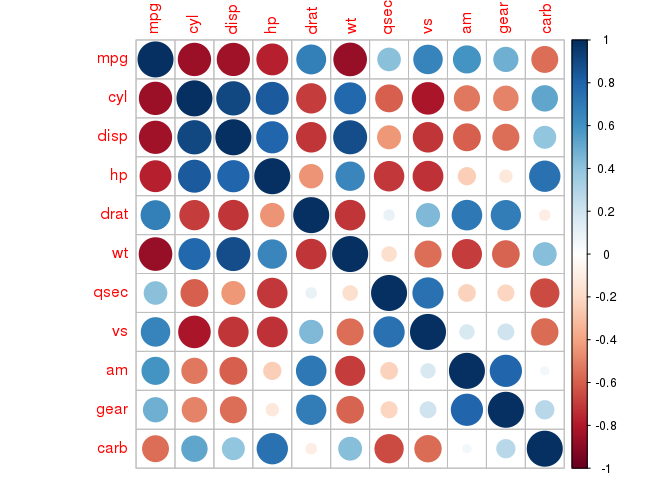

```r
library(corrplot)
corrplot(car_cor)
```

출력된 히트맵을 보면 상관계수가 클수록 원의 크기가 크고 색깔이 진한 것을 알 수 있다. 상관계수가 양수면 파란색, 음수면 빨간색 계열로 표현되어 있다.

또한 파라미터를 이용해 그래프 형태를 다양하게 바꿀 수 있다. method = number로 지정하여 원 대신 상관계수가 표현된 그래프이다.

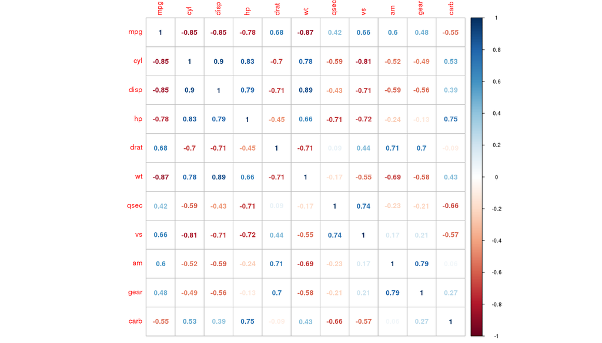

```r
corrplot(car_cor, method = "number")
```

### 색상 변경

이번에는 다양한 파라미터를 지정해 보자. 그래프 색깔을 바꾸기 위해 colorRampPalette() 함수를 사용해 색상 코드 목록을 생성하는 col() 함수를 만들어 파라미터에 활용해보았다.

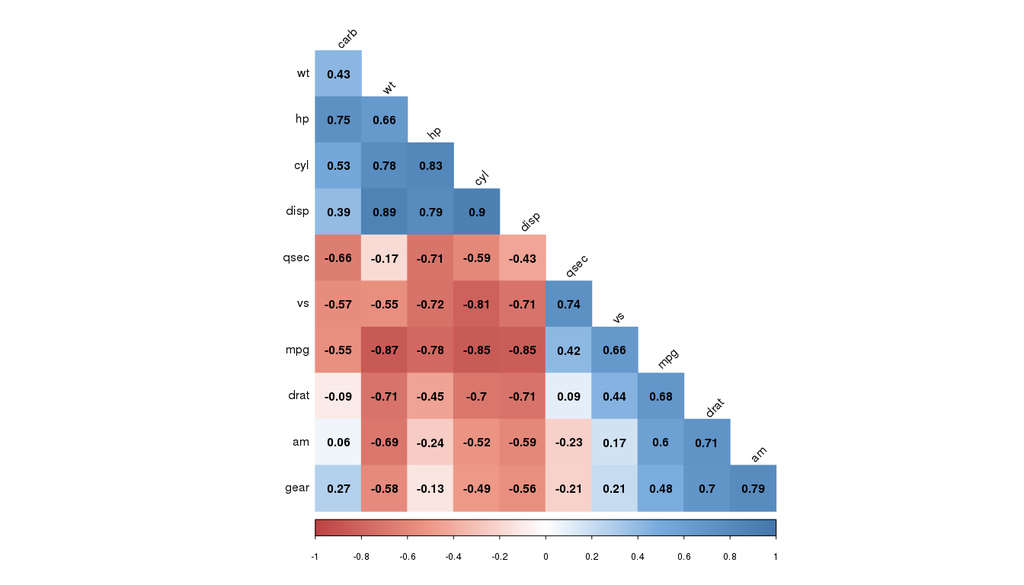

```r
col <- colorRampPalette(c("#BB4444", "#EE9988", "#FFFFFF", "#77AADD", "#4477AA"))

corrplot(car_cor,
         method = "color",
         col = col(200),
         type = "lower",
         order = "hclust",
         addCoef.col = "black",
         tl.col = "black",
         tl.srt = 45,
         diag = FALSE)
```

# 정리

교재를 참고하여 통계적 가설 검증에 대해 알아보았다. 단순하게 숫자를 넘어서 어떻게 해당 데이터가 통계적으로 유의하다고 이야기 할 수 있는지 t-test를 통해 알아보았다. 또 변수간의 관계성의 강도를 측정하는 상관분석에 대해 알아보았다. 데이터를 다루는 사람이라면 스스로가 만든 데이터가 목표달성에 어떻게 도움을 줄 수 있는지, 얼마만큼 의미가 있는지를 이야기할 수 있어야하기 때문에 이러한 가설에 대한 검증은 필연적으로 수반되어야 하는 부분일 것이다.